# HIS Data Analysis

Mike

2025-06-30

## Importing Data and Preprocessing

Our raw dataset consists of a file which includes data for each trial. Each participant also completed a survey, which we can match to the trial data with the prolific ID. We first preprocess the data by converting each column into their proper data types.

```r
data_raw <- fromJSON("fullstudy.combined.json")
survey_raw <- fromJSON("fullstudy.surveys.json")

numeric_cols_data <- c("aha1", "aha2", "aha3", "correctValue", "completedLevel", "completedEarly", "difficultyValue", "durationAfterBreak",
                  "durationBeforeBreak", "durationBreak", "durationToBeatGame", "idleTime",
                  "incorrectValue", "nm1", "nm2", "nm3", "r1b", "r2b", "r3b", "scrollCount",
                  "sessionID", "stuckValue", "e1", "e2", "e3", "f1", "f2", "f3", "mw1", "mw2",
                  "mw3", "pw", "r1", "r2", "r3", "ra")

factor_cols_data <- c("condition", "levelNumber","prolificPID")

numeric_cols_survey <- c("age")

factor_cols_survey <- c("sex", "handedness", "trialOrder", "conditionOrder")

data_raw <- data_raw %>%
  mutate(
    across(all_of(numeric_cols_data), ~ as.numeric(.)),
    across(all_of(factor_cols_data), ~ as.factor(.)),
    condition = recode(condition,
                       "1" = "No Break",
                       "2" = "Non-HIS",
                       "3" = "HIS"
                       )
  )

survey_raw <- survey_raw %>%
  mutate(
    across(all_of(numeric_cols_survey), ~ as.numeric(.)),
    across(all_of(factor_cols_survey), ~ as.factor(.)),
    across(c(videoGameHours, smartphoneHours, digitalDeviceHours, shortFormVideoHours),
           ~ as.numeric(recode(.,
                               "lessThan1" = 1,
                               "1to2" = 2,
                               "2to3" = 3,
                               "3to4" = 4,
                               "5plus" = 5))),
    sokobanFamiliarity = as.numeric(recode(sokobanFamiliarity,
                            "notFamiliar" = 1,
                            "somewhatFamiliar" = 2,
                            "veryFamiliar" = 3
                                           ))
  )
```

The raw dataset consists of 1039 trials.

```r
dim(data_raw)
```

```
## [1] 1039   44
```

```r
names(data_raw)
```

```
##  [1] "_id"                 "afterBreakMovesets"  "aha1"
##  [4] "aha2"                "aha3"                "beforeBreakMovesets"
##  [7] "completedEarly"      "completedLevel"      "condition"
## [10] "correctValue"        "difficultyValue"     "durationAfterBreak"
## [13] "durationBeforeBreak" "durationBreak"       "durationToBeatGame"
## [16] "idleTime"            "incorrectValue"      "levelNumber"
## [19] "nm1"                 "nm2"                 "nm3"
## [22] "playerId"            "prolificPID"         "r1b"
## [25] "r2b"                 "r3b"                 "scrollCount"
## [28] "sessionID"           "stuckValue"          "studyID"
## [31] "e1"                  "e2"                  "e3"
## [34] "f1"                  "f2"                  "f3"
## [37] "mw1"                 "mw2"                 "mw3"
## [40] "pw"                  "r1"                  "r2"
## [43] "r3"                  "ra"
```

The survey form recorded 351 submissions.

```r
dim(survey_raw)
```

```
## [1] 351  17
```

```r
names(survey_raw)
```

```
##  [1] "_id"                 "age"                 "sex"
##  [4] "handedness"          "videoGameHours"      "smartphoneHours"
##  [7] "sokobanFamiliarity"  "digitalDeviceHours"  "comments"
## [10] "playerId"            "shortFormVideoHours" "prolificPID"
## [13] "sessionID"           "studyID"             "trialOrder"
## [16] "conditionOrder"      "completedAllLevels"
```

## Exclusions

Note that there is not the expected ratio of 3 trials to 1 participant. This is because some individuals either timed out by being idle or did not complete the three practice trials within 10 minutes.Some participants also completed trials multiple times, likely because they refreshed the page or restarted the study. Furthermore, form submissions were sometimes duplicated internally. Some participants’ data were also not recorded for some trials, so we decide to remove all of their trials.

```r
problematic_ids <- data_raw %>%
  group_by(prolificPID) %>%
  summarise(row_count = n()) %>%
  filter(row_count != 3) %>%
  pull(prolificPID)

data <- data_raw %>%
  filter(
    !prolificPID %in% problematic_ids,
    prolificPID %in% survey_raw$prolificPID
    )

nrow(data)
```

```
## [1] 963
```

```r
survey <- survey_raw %>%
  filter(
    completedAllLevels != 0,
    prolificPID %in% data$prolificPID,
    ) %>%
  distinct(prolificPID, .keep_all = TRUE)


nrow(survey)
```

```
## [1] 321
```

Aside from these technical exclusions, we decided to improve the quality of data by removing participants that showed very low engagement. We are careful in excluding people here and use multiple criteria to decide. We only consider participants that did not complete any of the three levels. We check whether these participants had ALL of the following:

- low number of move sets made
- high idle time
- low accuracy or quantity of responses on the choice reaction task (classify odd and even numbers)

```r
participants_excluded <- data %>%
  group_by(prolificPID) %>%
  filter(
    all(completedLevel == 0),
    all(lengths(afterBreakMovesets) < 4),
    all(lengths(beforeBreakMovesets) < 4),
    mean(idleTime) > 200,
    any(condition == "Non-HIS" & incorrectValue + correctValue < 10)
  )

nrow(participants_excluded)
```

```
## [1] 0
```

```r
data <- data %>%
  filter(!prolificPID %in% participants_excluded$prolificPID)
```

## Validity and Reliability of Measures

For each construct, we use each participant’s first possible use of the scale during the first trial (since participants could possibly respond to each scale multiple times). This would exclude participants who completed the puzzle early on their first trial and those that are in the no break condition for the first puzzle. Below, the trial order is taken from the survey data set.

```r
items <- data %>%
  filter(completedEarly == 0, condition != "No Break") %>%
  left_join(
    survey %>%
      mutate(first_trial = substr(trialOrder, 1, 1)) %>%
      select(prolificPID, first_trial),
    by = "prolificPID"
  ) %>%
  filter(levelNumber == first_trial) %>%
  select(starts_with("aha"), starts_with("nm"), starts_with("e"), starts_with("f"), starts_with("mw"), r1b, r2b, r3b, -first_trial) %>%
  drop_na()
```

We first use confirmatory factor analysis to check for convergent and divergent validity. Important variables include those used as a manipulation check (heightened enjoyment, focused immersion, and mind-wandering, insight experience) and supplemental variables (perceived use of new moves, resources).

```r
fa_results <- fa(items, nfactors = 6, rotate = "oblimin")
fa_results
```

```
## Factor Analysis using method =  minres
## Call: fa(r = items, nfactors = 6, rotate = "oblimin")
## Standardized loadings (pattern matrix) based upon correlation matrix
##        MR3   MR1   MR2   MR5   MR4   MR6   h2    u2 com
## aha1  0.01 -0.07  0.91 -0.01 -0.01 -0.09 0.79 0.207 1.0
## aha2 -0.05  0.02  0.95  0.06 -0.04  0.09 0.95 0.046 1.0
## aha3  0.05  0.05  0.86 -0.01  0.09  0.00 0.79 0.208 1.0
## nm1   0.02 -0.10  0.02  0.85  0.06 -0.01 0.81 0.195 1.0
## nm2  -0.02 -0.03 -0.01  0.93 -0.03  0.00 0.83 0.175 1.0
## nm3   0.07  0.10  0.05  0.87  0.01 -0.01 0.85 0.154 1.0
## e1    0.91  0.03  0.02  0.03 -0.09  0.10 0.91 0.086 1.1
## e2    0.94  0.02  0.03  0.01  0.03  0.01 0.90 0.100 1.0
## e3    0.86 -0.10 -0.07  0.02  0.09 -0.06 0.79 0.207 1.1
## f1    0.02 -0.01 -0.05  0.04 -0.02  0.77 0.61 0.390 1.0
## f2    0.02 -0.13  0.06  0.02  0.09  0.69 0.72 0.283 1.1
## f3    0.22 -0.15  0.09 -0.15  0.07  0.59 0.73 0.271 1.7
## mw1   0.07  0.87 -0.02  0.01 -0.09  0.01 0.73 0.270 1.0
## mw2  -0.04  0.92 -0.03 -0.03  0.04 -0.04 0.95 0.055 1.0
## mw3  -0.06  0.83  0.05  0.00  0.04 -0.06 0.79 0.211 1.0
## r1b   0.09 -0.01  0.05  0.00  0.75 -0.03 0.60 0.395 1.0
## r2b   0.00 -0.02  0.03 -0.02  0.91 -0.01 0.84 0.164 1.0
## r3b  -0.11  0.07 -0.06  0.20  0.63  0.20 0.56 0.436 1.5
##
##                        MR3  MR1  MR2  MR5  MR4  MR6
## SS loadings           2.71 2.60 2.56 2.50 1.98 1.80
## Proportion Var        0.15 0.14 0.14 0.14 0.11 0.10
## Cumulative Var        0.15 0.29 0.44 0.58 0.69 0.79
## Proportion Explained  0.19 0.18 0.18 0.18 0.14 0.13
## Cumulative Proportion 0.19 0.38 0.56 0.73 0.87 1.00
##
##  With factor correlations of
##       MR3   MR1   MR2   MR5   MR4   MR6
## MR3  1.00 -0.46  0.16  0.33  0.17  0.56
## MR1 -0.46  1.00 -0.11 -0.06 -0.17 -0.65
## MR2  0.16 -0.11  1.00  0.52  0.30  0.18
## MR5  0.33 -0.06  0.52  1.00  0.38  0.16
## MR4  0.17 -0.17  0.30  0.38  1.00  0.31
## MR6  0.56 -0.65  0.18  0.16  0.31  1.00
##
## Mean item complexity =  1.1
## Test of the hypothesis that 6 factors are sufficient.
##
## df null model =  153  with the objective function =  16.48 with Chi Square =  2293.8
## df of  the model are 60  and the objective function was  0.78
##
## The root mean square of the residuals (RMSR) is  0.01
## The df corrected root mean square of the residuals is  0.02
##
## The harmonic n.obs is  147 with the empirical chi square  8.07  with prob <  1
## The total n.obs was  147  with Likelihood Chi Square =  105.18  with prob <  0.00028
##
## Tucker Lewis Index of factoring reliability =  0.944
## RMSEA index =  0.071  and the 90 % confidence intervals are  0.048 0.094
## BIC =  -194.24
## Fit based upon off diagonal values = 1
## Measures of factor score adequacy
##                                                    MR3  MR1  MR2  MR5  MR4  MR6
## Correlation of (regression) scores with factors   0.98 0.98 0.98 0.97 0.94 0.93
## Multiple R square of scores with factors          0.96 0.96 0.97 0.93 0.89 0.86
## Minimum correlation of possible factor scores     0.92 0.92 0.93 0.87 0.78 0.72
```

We assess internal consistency using Cronbach’s alpha.

```r
alpha(items[,1:3]) # insight experience
```

```
##
## Reliability analysis
## Call: alpha(x = items[, 1:3])
##
##   raw_alpha std.alpha G6(smc) average_r S/N    ase mean  sd median_r
##       0.94      0.94    0.92      0.83  15 0.0091  4.1 1.9     0.86
##
##     95% confidence boundaries
##          lower alpha upper
## Feldt     0.92  0.94  0.95
## Duhachek  0.92  0.94  0.95
##
##  Reliability if an item is dropped:
##      raw_alpha std.alpha G6(smc) average_r  S/N alpha se var.r med.r
## aha1      0.93      0.93    0.87      0.87 12.9    0.012    NA  0.87
## aha2      0.88      0.88    0.78      0.78  7.3    0.020    NA  0.78
## aha3      0.92      0.92    0.86      0.86 11.8    0.013    NA  0.86
##
##  Item statistics
##        n raw.r std.r r.cor r.drop mean  sd
## aha1 147  0.94  0.93  0.88   0.85  3.8 2.1
## aha2 147  0.96  0.96  0.94   0.91  4.2 2.0
## aha3 147  0.93  0.94  0.89   0.85  4.3 1.9
##
## Non missing response frequency for each item
##         1    2    3    4    5    6    7 miss
## aha1 0.18 0.25 0.05 0.06 0.18 0.14 0.14    0
## aha2 0.12 0.20 0.06 0.05 0.25 0.20 0.12    0
## aha3 0.10 0.17 0.05 0.14 0.24 0.14 0.16    0
```

```r
alpha(items[,4:6]) # perceived use of new moves
```

```
##
## Reliability analysis
## Call: alpha(x = items[, 4:6])
##
##   raw_alpha std.alpha G6(smc) average_r S/N  ase mean  sd median_r
##       0.93      0.93     0.9      0.81  13 0.01  5.3 1.3     0.81
##
##     95% confidence boundaries
##          lower alpha upper
## Feldt     0.91  0.93  0.95
## Duhachek  0.91  0.93  0.95
##
##  Reliability if an item is dropped:
##     raw_alpha std.alpha G6(smc) average_r S/N alpha se var.r med.r
## nm1      0.90      0.90    0.82      0.82 9.2    0.016    NA  0.82
## nm2      0.89      0.90    0.81      0.81 8.6    0.017    NA  0.81
## nm3      0.89      0.89    0.81      0.81 8.5    0.017    NA  0.81
##
##  Item statistics
##       n raw.r std.r r.cor r.drop mean  sd
## nm1 147  0.94  0.93  0.88   0.85  5.3 1.5
## nm2 147  0.94  0.94  0.89   0.86  5.3 1.4
## nm3 147  0.93  0.94  0.89   0.86  5.3 1.4
##
## Non missing response frequency for each item
##        1    2    3    4    5    6    7 miss
## nm1 0.01 0.07 0.07 0.05 0.24 0.39 0.16    0
## nm2 0.02 0.03 0.10 0.03 0.28 0.35 0.18    0
## nm3 0.01 0.03 0.07 0.07 0.27 0.37 0.16    0
```

```r
alpha(items[,7:9]) # heightened enjoyment
```

```
##
## Reliability analysis
## Call: alpha(x = items[, 7:9])
##
##   raw_alpha std.alpha G6(smc) average_r S/N    ase mean  sd median_r
##       0.95      0.95    0.93      0.86  18 0.0079  4.5 1.8     0.84
##
##     95% confidence boundaries
##          lower alpha upper
## Feldt     0.93  0.95  0.96
## Duhachek  0.93  0.95  0.96
##
##  Reliability if an item is dropped:
##    raw_alpha std.alpha G6(smc) average_r  S/N alpha se var.r med.r
## e1      0.91      0.91    0.83      0.83  9.9    0.015    NA  0.83
## e2      0.91      0.91    0.84      0.84 10.6    0.014    NA  0.84
## e3      0.95      0.95    0.90      0.90 17.3    0.009    NA  0.90
##
##  Item statistics
##      n raw.r std.r r.cor r.drop mean  sd
## e1 147  0.96  0.96  0.94   0.91  4.5 1.8
## e2 147  0.95  0.96  0.93   0.90  4.6 1.9
## e3 147  0.94  0.94  0.88   0.86  4.2 2.1
##
## Non missing response frequency for each item
##       1    2    3    4    5    6    7 miss
## e1 0.06 0.16 0.05 0.19 0.14 0.27 0.14    0
## e2 0.07 0.13 0.09 0.12 0.16 0.28 0.16    0
## e3 0.12 0.17 0.12 0.10 0.14 0.19 0.18    0
```

```r
alpha(items[,10:12]) # focused immersion
```

```
##
## Reliability analysis
## Call: alpha(x = items[, 10:12])
##
##   raw_alpha std.alpha G6(smc) average_r S/N   ase mean  sd median_r
##       0.86      0.85     0.8      0.66 5.9 0.021  4.8 1.4     0.64
##
##     95% confidence boundaries
##          lower alpha upper
## Feldt     0.81  0.86  0.89
## Duhachek  0.81  0.86  0.90
##
##  Reliability if an item is dropped:
##    raw_alpha std.alpha G6(smc) average_r S/N alpha se var.r med.r
## f1      0.84      0.84    0.72      0.72 5.1    0.027    NA  0.72
## f2      0.77      0.77    0.63      0.63 3.4    0.038    NA  0.63
## f3      0.78      0.78    0.64      0.64 3.6    0.036    NA  0.64
##
##  Item statistics
##      n raw.r std.r r.cor r.drop mean  sd
## f1 147  0.85  0.86  0.74   0.68  5.0 1.6
## f2 147  0.90  0.89  0.82   0.75  4.8 1.7
## f3 147  0.89  0.89  0.81   0.75  4.7 1.7
##
## Non missing response frequency for each item
##       1    2    3    4    5    6    7 miss
## f1 0.03 0.05 0.11 0.16 0.18 0.32 0.15    0
## f2 0.01 0.11 0.17 0.10 0.18 0.27 0.16    0
## f3 0.02 0.11 0.15 0.15 0.14 0.31 0.12    0
```

```r
alpha(items[,13:15]) # mind-wandering
```

```
##
## Reliability analysis
## Call: alpha(x = items[, 13:15])
##
##   raw_alpha std.alpha G6(smc) average_r S/N   ase mean  sd median_r
##       0.93      0.93     0.9      0.81  12 0.011  3.9 1.8     0.82
##
##     95% confidence boundaries
##          lower alpha upper
## Feldt      0.9  0.93  0.94
## Duhachek   0.9  0.93  0.95
##
##  Reliability if an item is dropped:
##     raw_alpha std.alpha G6(smc) average_r  S/N alpha se var.r med.r
## mw1      0.93      0.93    0.86      0.86 12.4    0.012    NA  0.86
## mw2      0.85      0.85    0.74      0.74  5.6    0.025    NA  0.74
## mw3      0.90      0.90    0.82      0.82  9.1    0.016    NA  0.82
##
##  Item statistics
##       n raw.r std.r r.cor r.drop mean  sd
## mw1 147  0.91  0.91  0.84   0.81  4.0 1.9
## mw2 147  0.96  0.96  0.94   0.90  3.7 1.9
## mw3 147  0.93  0.93  0.88   0.84  4.0 1.9
##
## Non missing response frequency for each item
##        1    2    3    4    5    6    7 miss
## mw1 0.12 0.18 0.13 0.07 0.22 0.20 0.07    0
## mw2 0.13 0.24 0.11 0.08 0.21 0.17 0.05    0
## mw3 0.10 0.22 0.10 0.07 0.24 0.20 0.06    0
```

```r
alpha(items[,16:18]) # resources
```

```
##
## Reliability analysis
## Call: alpha(x = items[, 16:18])
##
##   raw_alpha std.alpha G6(smc) average_r S/N   ase mean   sd median_r
##       0.84      0.84    0.79      0.64 5.4 0.022  3.8 0.74     0.66
##
##     95% confidence boundaries
##          lower alpha upper
## Feldt     0.79  0.84  0.88
## Duhachek  0.80  0.84  0.89
##
##  Reliability if an item is dropped:
##     raw_alpha std.alpha G6(smc) average_r S/N alpha se var.r med.r
## r1b      0.79      0.80    0.66      0.66 3.9    0.034    NA  0.66
## r2b      0.71      0.71    0.55      0.55 2.5    0.048    NA  0.55
## r3b      0.83      0.83    0.71      0.71 4.9    0.028    NA  0.71
##
##  Item statistics
##       n raw.r std.r r.cor r.drop mean   sd
## r1b 147  0.87  0.86  0.76   0.70  3.4 0.86
## r2b 147  0.91  0.91  0.85   0.78  3.8 0.88
## r3b 147  0.84  0.85  0.71   0.66  4.1 0.80
##
## Non missing response frequency for each item
##        1    2    3    4    5 miss
## r1b 0.01 0.09 0.50 0.27 0.14    0
## r2b 0.01 0.07 0.25 0.45 0.22    0
## r3b 0.00 0.04 0.13 0.47 0.36    0
```

## General Performance

Completion data for each level

```r
completion <- data %>%
  group_by(levelNumber) %>%
  summarise(
    completed_count = sum(completedLevel),
    percent_completed = mean(completedLevel) * 100,
    sample_size = n()
  )

completion
```

```
## # A tibble: 3 × 4
##   levelNumber completed_count percent_completed sample_size
##   <fct>                 <dbl>             <dbl>       <int>
## 1 5                        89              27.7         321
## 2 7                       216              67.3         321
## 3 8                       171              53.3         321
```

Early completion (trials excluded from main analyses)

```r
early_completion <- data %>%
  group_by(levelNumber) %>%
    summarize(
      completed_early_count = sum(completedEarly),
      percent_completedearly = mean(completedEarly)*100,
      n = n()
    )

early_completion
```

```
## # A tibble: 3 × 4
##   levelNumber completed_early_count percent_completedearly     n
##   <fct>                       <dbl>                  <dbl> <int>
## 1 5                              49                   15.3   321
## 2 7                             156                   48.6   321
## 3 8                              95                   29.6   321
```

Completion duration

```r
completion_duration <- data %>%
  filter(completedLevel == 1) %>%
  mutate(
    durationBreak = replace_na(durationBreak, 0),
    totalTime = durationToBeatGame - durationBreak
    ) %>%
  group_by(levelNumber) %>%
    summarize(duration_to_beat_puzzle = mean(totalTime, na.rm = TRUE))

completion_duration
```

```
## # A tibble: 3 × 2
##   levelNumber duration_to_beat_puzzle
##   <fct>                         <dbl>
## 1 5                              162.
## 2 7                              102.
## 3 8                              148.
```

For the ease of interpretation, rather than referring to the levels using the internal numbers, we can now classify based on their actual difficulties.

```r
data <- data %>%
  mutate(levelNumber = recode(levelNumber,
                              `5` = "hard",
                              `7` = "easy",
                              `8` = "medium")) %>%
  rename(level = levelNumber) %>%
  mutate(level = factor(level, levels = c("easy", "medium", "hard")))
```

For participants who did not complete puzzles early, we obtained brief 1-item measures for perceived difficulty and impasse.

```r
difficulty <- data %>%
  group_by(level) %>%
    summarize(
      average_difficulty = mean(difficultyValue, na.rm = TRUE)
    )

difficulty
```

```
## # A tibble: 3 × 2
##   level  average_difficulty
##   <fct>               <dbl>
## 1 easy                 5.92
## 2 medium               6.00
## 3 hard                 5.88
```

```r
impasse <- data %>%
  group_by(level) %>%
  summarize(
    average_impasse = mean(stuckValue, na.rm = TRUE)
  )

impasse
```

```
## # A tibble: 3 × 2
##   level  average_impasse
##   <fct>            <dbl>
## 1 easy              5.61
## 2 medium            5.81
## 3 hard              5.58
```

## Manipulation Check

We first check whether the non-HIS and HIS condition were different from each other. Here, we average our items for each construct. For resources, we take the difference to get a measure of the changes in resources after taking a break.

```r
manipulation_data <- data %>%
  filter(condition != "No Break") %>%
  drop_na(f1, f2, f3, nm1, nm2, nm3, e1, e2, e3, mw1, mw2, mw3, r1b, r2b, r3b, r1, r2, r3, ra, pw) %>%
  mutate(
    focused_immersion = rowMeans(select(., f1, f2, f3)),
    heightened_enjoyment = rowMeans(select(., e1, e2, e3)),
    mind_wandering = rowMeans(select(., mw1, mw2, mw3)),
    perceived_use_of_new_strategies = rowMeans(select(., nm1, nm2, nm3)),
    resources_before = rowMeans(select(., r1b, r2b, r3b)),
    resources_after = rowMeans(select(., r1, r2, r3)),
    resources_difference = resources_after - resources_before
  )
```

Mixed effects models are used here to account for the repeated measures in our experiment (i.e., control for baseline differences among participants). Note that the intercept represents the value of the Non-HIS condition.

Focused immersion

```r
fi_lm <- lmer(focused_immersion ~ condition + (1|prolificPID), data = manipulation_data)
summary(fi_lm)
```

```
## Linear mixed model fit by REML. t-tests use Satterthwaite's method [
## lmerModLmerTest]
## Formula: focused_immersion ~ condition + (1 | prolificPID)
##    Data: manipulation_data
##
## REML criterion at convergence: 1492.8
##
## Scaled residuals:
##      Min       1Q   Median       3Q      Max
## -2.48028 -0.62617 -0.00492  0.69093  1.83590
##
## Random effects:
##  Groups      Name        Variance Std.Dev.
##  prolificPID (Intercept) 0.6003   0.7748
##  Residual                1.5411   1.2414
## Number of obs: 417, groups:  prolificPID, 274
##
## Fixed effects:
##               Estimate Std. Error        df t value Pr(>|t|)
## (Intercept)    4.39069    0.09991 411.29457   43.95  < 2e-16 ***
## conditionHIS   0.64177    0.12733 229.48911    5.04 9.43e-07 ***
## ---
## Signif. codes:  0 '***' 0.001 '**' 0.01 '*' 0.05 '.' 0.1 ' ' 1
##
## Correlation of Fixed Effects:
##             (Intr)
## conditinHIS -0.628
```

Heightened enjoyment

```r
he_lm <- lmer(heightened_enjoyment ~ condition + (1|prolificPID), data = manipulation_data)
summary(he_lm)
```

```
## Linear mixed model fit by REML. t-tests use Satterthwaite's method [
## lmerModLmerTest]
## Formula: heightened_enjoyment ~ condition + (1 | prolificPID)
##    Data: manipulation_data
##
## REML criterion at convergence: 1567.7
##
## Scaled residuals:
##     Min      1Q  Median      3Q     Max
## -2.6268 -0.7896  0.1555  0.7042  2.1426
##
## Random effects:
##  Groups      Name        Variance Std.Dev.
##  prolificPID (Intercept) 0.2752   0.5246
##  Residual                2.2295   1.4931
## Number of obs: 417, groups:  prolificPID, 274
##
## Fixed effects:
##              Estimate Std. Error       df t value Pr(>|t|)
## (Intercept)    3.4058     0.1088 414.4863   31.30   <2e-16 ***
## conditionHIS   1.9187     0.1488 244.2430   12.89   <2e-16 ***
## ---
## Signif. codes:  0 '***' 0.001 '**' 0.01 '*' 0.05 '.' 0.1 ' ' 1
##
## Correlation of Fixed Effects:
##             (Intr)
## conditinHIS -0.675
```

Mind-wandering

```r
mw_lm <- lmer(mind_wandering ~ condition + (1|prolificPID), data = manipulation_data)
summary(mw_lm)
```

```
## Linear mixed model fit by REML. t-tests use Satterthwaite's method [
## lmerModLmerTest]
## Formula: mind_wandering ~ condition + (1 | prolificPID)
##    Data: manipulation_data
##
## REML criterion at convergence: 1652.9
##
## Scaled residuals:
##     Min      1Q  Median      3Q     Max
## -2.0354 -0.7461  0.1294  0.6687  1.8840
##
## Random effects:
##  Groups      Name        Variance Std.Dev.
##  prolificPID (Intercept) 1.122    1.059
##  Residual                2.081    1.443
## Number of obs: 417, groups:  prolificPID, 274
##
## Fixed effects:
##              Estimate Std. Error       df t value Pr(>|t|)
## (Intercept)    4.2608     0.1216 408.5835  35.035  < 2e-16 ***
## conditionHIS  -0.6040     0.1498 218.6782  -4.032 7.63e-05 ***
## ---
## Signif. codes:  0 '***' 0.001 '**' 0.01 '*' 0.05 '.' 0.1 ' ' 1
##
## Correlation of Fixed Effects:
##             (Intr)
## conditinHIS -0.607
```

Active work on the puzzle during the break

```r
pw_lm <- lmer(pw ~ condition + (1|prolificPID), data = manipulation_data)
summary(pw_lm)
```

```
## Linear mixed model fit by REML. t-tests use Satterthwaite's method [
## lmerModLmerTest]
## Formula: pw ~ condition + (1 | prolificPID)
##    Data: manipulation_data
##
## REML criterion at convergence: 1546.2
##
## Scaled residuals:
##     Min      1Q  Median      3Q     Max
## -2.4993 -0.4819 -0.1595  0.2598  3.3598
##
## Random effects:
##  Groups      Name        Variance Std.Dev.
##  prolificPID (Intercept) 1.442    1.201
##  Residual                1.224    1.106
## Number of obs: 417, groups:  prolificPID, 274
##
## Fixed effects:
##              Estimate Std. Error       df t value Pr(>|t|)
## (Intercept)    2.6442     0.1088 395.3834  24.293  < 2e-16 ***
## conditionHIS  -0.4831     0.1189 196.7091  -4.061 7.05e-05 ***
## ---
## Signif. codes:  0 '***' 0.001 '**' 0.01 '*' 0.05 '.' 0.1 ' ' 1
##
## Correlation of Fixed Effects:
##             (Intr)
## conditinHIS -0.538
```

Changes in resources

```r
rd_lm <- lmer(resources_difference ~ condition + (1|prolificPID), data = manipulation_data)
summary(rd_lm)
```

```
## Linear mixed model fit by REML. t-tests use Satterthwaite's method [
## lmerModLmerTest]
## Formula: resources_difference ~ condition + (1 | prolificPID)
##    Data: manipulation_data
##
## REML criterion at convergence: 732.1
##
## Scaled residuals:
##      Min       1Q   Median       3Q      Max
## -2.89186 -0.52224 -0.02161  0.42951  3.12459
##
## Random effects:
##  Groups      Name        Variance Std.Dev.
##  prolificPID (Intercept) 0.0720   0.2683
##  Residual                0.2664   0.5161
## Number of obs: 417, groups:  prolificPID, 274
##
## Fixed effects:
##               Estimate Std. Error        df t value Pr(>|t|)
## (Intercept)   -0.23649    0.03986 413.00556  -5.933 6.29e-09 ***
## conditionHIS   0.25065    0.05233 237.46268   4.790 2.94e-06 ***
## ---
## Signif. codes:  0 '***' 0.001 '**' 0.01 '*' 0.05 '.' 0.1 ' ' 1
##
## Correlation of Fixed Effects:
##             (Intr)
## conditinHIS -0.648
```

Perceived recovery after break

```r
r_lm <- lmer(ra ~ condition + (1|prolificPID), data = manipulation_data)
summary(r_lm)
```

```
## Linear mixed model fit by REML. t-tests use Satterthwaite's method [
## lmerModLmerTest]
## Formula: ra ~ condition + (1 | prolificPID)
##    Data: manipulation_data
##
## REML criterion at convergence: 1569.1
##
## Scaled residuals:
##      Min       1Q   Median       3Q      Max
## -2.52563 -0.50078  0.09323  0.63438  1.81586
##
## Random effects:
##  Groups      Name        Variance Std.Dev.
##  prolificPID (Intercept) 0.6527   0.8079
##  Residual                1.9079   1.3813
## Number of obs: 417, groups:  prolificPID, 274
##
## Fixed effects:
##              Estimate Std. Error       df t value Pr(>|t|)
## (Intercept)    3.8272     0.1094 411.7866  34.979  < 2e-16 ***
## conditionHIS   0.9968     0.1411 224.8117   7.067 1.97e-11 ***
## ---
## Signif. codes:  0 '***' 0.001 '**' 0.01 '*' 0.05 '.' 0.1 ' ' 1
##
## Correlation of Fixed Effects:
##             (Intr)
## conditinHIS -0.636
```

Perceived use of new strategies/moves after a break

```r
nm_lm <- lmer(perceived_use_of_new_strategies ~ condition + (1|prolificPID), data = manipulation_data)
summary(nm_lm)
```

```
## Linear mixed model fit by REML. t-tests use Satterthwaite's method [
## lmerModLmerTest]
## Formula: perceived_use_of_new_strategies ~ condition + (1 | prolificPID)
##    Data: manipulation_data
##
## REML criterion at convergence: 1448
##
## Scaled residuals:
##     Min      1Q  Median      3Q     Max
## -2.9810 -0.3577  0.2388  0.4985  1.8763
##
## Random effects:
##  Groups      Name        Variance Std.Dev.
##  prolificPID (Intercept) 0.5365   0.7325
##  Residual                1.3853   1.1770
## Number of obs: 417, groups:  prolificPID, 274
##
## Fixed effects:
##               Estimate Std. Error        df t value Pr(>|t|)
## (Intercept)    5.18596    0.09466 411.92761  54.787   <2e-16 ***
## conditionHIS   0.06474    0.12070 247.80366   0.536    0.592
## ---
## Signif. codes:  0 '***' 0.001 '**' 0.01 '*' 0.05 '.' 0.1 ' ' 1
##
## Correlation of Fixed Effects:
##             (Intr)
## conditinHIS -0.629
```

If Sokoban is a suitable non-routine problem, participants may have insight experiences if they are able to solve the puzzles. They should be more likely to have insight experiences after returning from a break, compared to those that completed the puzzle early.

```r
insight_data  <- data %>%
  drop_na(aha1, aha2, aha3) %>%
  mutate(
    aha = rowMeans(select(., aha1, aha2, aha3))
  )

i_lm <- lmer(aha ~ completedLevel + completedEarly + (1|prolificPID), data = insight_data)
summary(i_lm)
```

```
## Linear mixed model fit by REML. t-tests use Satterthwaite's method [
## lmerModLmerTest]
## Formula: aha ~ completedLevel + completedEarly + (1 | prolificPID)
##    Data: insight_data
##
## REML criterion at convergence: 3286.1
##
## Scaled residuals:
##     Min      1Q  Median      3Q     Max
## -3.5284 -0.6089  0.0623  0.5510  2.4395
##
## Random effects:
##  Groups      Name        Variance Std.Dev.
##  prolificPID (Intercept) 0.8724   0.934
##  Residual                1.1998   1.095
## Number of obs: 963, groups:  prolificPID, 321
##
## Fixed effects:
##                 Estimate Std. Error        df t value Pr(>|t|)
## (Intercept)      3.22498    0.07507 531.77056  42.958  < 2e-16 ***
## completedLevel   2.88389    0.11144 839.59457  25.877  < 2e-16 ***
## completedEarly  -0.49350    0.11942 828.39686  -4.133 3.95e-05 ***
## ---
## Signif. codes:  0 '***' 0.001 '**' 0.01 '*' 0.05 '.' 0.1 ' ' 1
##
## Correlation of Fixed Effects:
##             (Intr) cmpltL
## completdLvl -0.402
## compltdErly -0.004 -0.670
```

Here, we can see participants rated higher insight (3.22 + 2.88) if they completed a level. However, if they completed a level early, their rating of perceived insight decreases (3.22 + 2.88 - .49).

## Main Analyses

First, we check if any of the control variables are relevant. Not enough participants identified as neither male or female at birth and as ambidextrous, so these participants are excluded. However, they are used in the main analyses if we exclude these variables in the models.

```r
main_data <- data %>%
  left_join(
    survey %>%
      select(prolificPID, age, handedness, sex, videoGameHours, smartphoneHours, sokobanFamiliarity, digitalDeviceHours, shortFormVideoHours, trialOrder, conditionOrder),
    by = "prolificPID"
  ) %>%
  filter(
    sex %in% c(0, 1), # 1 participant put other
    handedness %in% c("left","right"), # 5 participants put ambidextrous
    prolificPID != "6466190f0491049a32d5b0fc", # this participant put an invalid age (-57)
    completedEarly != 1 # include only those who encountered manipulations
    ) %>%
  mutate(sex = factor(sex, levels = c(0, 1), labels = c("Female", "Male")),)
```

We set our base model as the one which includes our key predictor (condition) and puzzle level (due to inherent differences in difficulty). We include participant ID (prolificPID) as a random intercept to account for repeated measures within participants.

```r
model1_base <- glmer(completedLevel ~  level * condition + (1|prolificPID), family="binomial", control = glmerControl(optimizer = "bobyqa"), data = main_data)

summary(model1_base)
```

```
## Generalized linear mixed model fit by maximum likelihood (Laplace
##   Approximation) [glmerMod]
##  Family: binomial  ( logit )
## Formula: completedLevel ~ level * condition + (1 | prolificPID)
##    Data: main_data
## Control: glmerControl(optimizer = "bobyqa")
##
##       AIC       BIC    logLik -2*log(L)  df.resid
##     735.9     780.7    -358.0     715.9       643
##
## Scaled residuals:
##     Min      1Q  Median      3Q     Max
## -0.9793 -0.6038 -0.3890  0.9190  2.7146
##
## Random effects:
##  Groups      Name        Variance Std.Dev.
##  prolificPID (Intercept) 0.6125   0.7826
## Number of obs: 653, groups:  prolificPID, 298
##
## Fixed effects:
##                              Estimate Std. Error z value Pr(>|z|)
## (Intercept)                  -0.66748    0.31385  -2.127   0.0334 *
## levelmedium                   0.07217    0.40768   0.177   0.8595
## levelhard                    -0.96992    0.43358  -2.237   0.0253 *
## conditionNon-HIS             -0.15322    0.44626  -0.343   0.7313
## conditionHIS                  0.38831    0.45299   0.857   0.3913
## levelmedium:conditionNon-HIS -0.27796    0.60205  -0.462   0.6443
## levelhard:conditionNon-HIS   -0.30745    0.64204  -0.479   0.6320
## levelmedium:conditionHIS     -0.49543    0.60427  -0.820   0.4123
## levelhard:conditionHIS       -0.86620    0.64326  -1.347   0.1781
## ---
## Signif. codes:  0 '***' 0.001 '**' 0.01 '*' 0.05 '.' 0.1 ' ' 1
##
## Correlation of Fixed Effects:
##             (Intr) lvlmdm lvlhrd cN-HIS cndHIS lvlm:N-HIS lvlh:N-HIS lvlm:HIS
## levelmedium -0.758
## levelhard   -0.701  0.559
## cndtnNn-HIS -0.688  0.557  0.531
## conditinHIS -0.692  0.539  0.501  0.476
## lvlmd:N-HIS  0.530 -0.705 -0.394 -0.765 -0.368
## lvlhr:N-HIS  0.493 -0.387 -0.685 -0.712 -0.343  0.530
## lvlmdm:cHIS  0.533 -0.694 -0.377 -0.372 -0.769  0.475      0.261
## lvlhrd:cHIS  0.506 -0.380 -0.664 -0.339 -0.728  0.257      0.451      0.545
```

We compare our base model to models including one control variable.

```r
model1_age <- glmer(completedLevel ~  level * condition + age + (1|prolificPID), family="binomial", control = glmerControl(optimizer = "bobyqa"), data = main_data)

model1_sex <- glmer(completedLevel ~  level * condition + sex + (1|prolificPID), family="binomial", control = glmerControl(optimizer = "bobyqa"), data = main_data)

model1_handedness <- glmer(completedLevel ~  level * condition + handedness + (1|prolificPID), family="binomial", control = glmerControl(optimizer = "bobyqa"), data = main_data)

model1_videoGames <- glmer(completedLevel ~  level * condition + videoGameHours + (1|prolificPID), family="binomial", control = glmerControl(optimizer = "bobyqa"), data = main_data)

model1_smartphones <- glmer(completedLevel ~  level * condition + smartphoneHours + (1|prolificPID), family="binomial", control = glmerControl(optimizer = "bobyqa"), data = main_data)

model1_sokoban <- glmer(completedLevel ~  level * condition + sokobanFamiliarity + (1|prolificPID), family="binomial", control = glmerControl(optimizer = "bobyqa"), data = main_data)

model1_digitalDevice <- glmer(completedLevel ~  level * condition + digitalDeviceHours + (1|prolificPID), family="binomial", control = glmerControl(optimizer = "bobyqa"), data = main_data)

model1_shortFormVideos <- glmer(completedLevel ~  level * condition + shortFormVideoHours + (1|prolificPID), family="binomial", control = glmerControl(optimizer = "bobyqa"), data = main_data)

model1_trialOrder <- glmer(completedLevel ~  level * condition + trialOrder + (1|prolificPID), family="binomial", control = glmerControl(optimizer = "bobyqa"), data = main_data)

model1_conditionOrder <- glmer(completedLevel ~  level * condition + conditionOrder + (1|prolificPID), family="binomial", control = glmerControl(optimizer = "bobyqa"), data = main_data)

models1 <- list(
  base = model1_base,
  age = model1_age,
  sex = model1_sex,
  handedness = model1_handedness,
  videoGames = model1_videoGames,
  smartphones = model1_smartphones,
  sokoban = model1_sokoban,
  digitalDevice = model1_digitalDevice,
  shortFormVideos = model1_shortFormVideos,
  trialOrder = model1_trialOrder,
  conditionOrder = model1_conditionOrder
)

aic_results1 <- sapply(models1, AIC)
aic_results1 <- sort(aic_results1)
aic_results1
```

```
##             sex             age      videoGames      trialOrder     smartphones
##        729.4485        732.8623        733.4923        733.6078        735.9198
##            base      handedness shortFormVideos   digitalDevice         sokoban
##        735.9274        736.3519        737.3182        737.8200        737.9216
##  conditionOrder
##        744.0089
```

```r
bic_results1 <- sapply(models1, BIC)
bic_results1 <- sort(bic_results1)
bic_results1
```

```
##             sex            base             age      videoGames     smartphones
##        778.7458        780.7432        782.1596        782.7897        785.2171
##      handedness shortFormVideos   digitalDevice         sokoban      trialOrder
##        785.6493        786.6155        787.1174        787.2189        800.8315
##  conditionOrder
##        811.2325
```

```r
anova(model1_sex, model1_base)
```

```
## Data: main_data
## Models:
## model1_base: completedLevel ~ level * condition + (1 | prolificPID)
## model1_sex: completedLevel ~ level * condition + sex + (1 | prolificPID)
##             npar    AIC    BIC  logLik -2*log(L)  Chisq Df Pr(>Chisq)
## model1_base   10 735.93 780.74 -357.96    715.93
## model1_sex    11 729.45 778.75 -353.72    707.45 8.4789  1   0.003593 **
## ---
## Signif. codes:  0 '***' 0.001 '**' 0.01 '*' 0.05 '.' 0.1 ' ' 1
```

The model using sex as a control variable seems to perform the best. Our study reports the results of this model, including the ambidextrous participants but leaving out the one participant that responded with “other” for sex. Note that both models agree in terms of what variable or interaction is significant. Males seem to perform considerably better than females on solving Sokoban puzzles.

```r
model1_data <- data %>%
  left_join(
    survey %>%
      select(sex, prolificPID),
    by = "prolificPID"
  ) %>%
  filter(sex %in% c(0, 1)) %>%
  mutate(sex = factor(sex, levels = c(0, 1), labels = c("Female", "Male")),)

model1_final <- glmer(completedLevel ~  level * condition + sex + (1|prolificPID), family="binomial", control = glmerControl(optimizer = "bobyqa"), data = model1_data)

summary(model1_final)
```

```
## Generalized linear mixed model fit by maximum likelihood (Laplace
##   Approximation) [glmerMod]
##  Family: binomial  ( logit )
## Formula: completedLevel ~ level * condition + sex + (1 | prolificPID)
##    Data: model1_data
## Control: glmerControl(optimizer = "bobyqa")
##
##       AIC       BIC    logLik -2*log(L)  df.resid
##    1210.9    1264.4    -594.4    1188.9       949
##
## Scaled residuals:
##     Min      1Q  Median      3Q     Max
## -1.8392 -0.7177 -0.3320  0.7138  2.1590
##
## Random effects:
##  Groups      Name        Variance Std.Dev.
##  prolificPID (Intercept) 0.7587   0.871
## Number of obs: 960, groups:  prolificPID, 320
##
## Fixed effects:
##                              Estimate Std. Error z value Pr(>|z|)
## (Intercept)                   0.47737    0.24584   1.942 0.052168 .
## levelmedium                  -0.68687    0.32847  -2.091 0.036516 *
## levelhard                    -1.83014    0.34761  -5.265  1.4e-07 ***
## conditionNon-HIS             -0.13701    0.32934  -0.416 0.677405
## conditionHIS                  0.41105    0.34067   1.207 0.227589
## sexMale                       0.62159    0.18086   3.437 0.000588 ***
## levelmedium:conditionNon-HIS  0.13009    0.47359   0.275 0.783551
## levelhard:conditionNon-HIS   -0.04365    0.49415  -0.088 0.929610
## levelmedium:conditionHIS     -0.21678    0.48295  -0.449 0.653533
## levelhard:conditionHIS       -0.53534    0.49494  -1.082 0.279416
## ---
## Signif. codes:  0 '***' 0.001 '**' 0.01 '*' 0.05 '.' 0.1 ' ' 1
##
## Correlation of Fixed Effects:
##             (Intr) lvlmdm lvlhrd cN-HIS cndHIS sexMal lvlm:N-HIS lvlh:N-HIS
## levelmedium -0.671
## levelhard   -0.634  0.498
## cndtnNn-HIS -0.654  0.528  0.509
## conditinHIS -0.628  0.495  0.459  0.467
## sexMale     -0.300 -0.018 -0.099 -0.037  0.014
## lvlmd:N-HIS  0.488 -0.732 -0.361 -0.737 -0.343  0.015
## lvlhr:N-HIS  0.451 -0.352 -0.699 -0.702 -0.329  0.054  0.491
## lvlmdm:cHIS  0.477 -0.705 -0.326 -0.350 -0.742 -0.031  0.490      0.234
## lvlhrd:cHIS  0.450 -0.338 -0.670 -0.338 -0.720  0.003  0.234      0.476
##             lvlm:HIS
## levelmedium
## levelhard
## cndtnNn-HIS
## conditinHIS
## sexMale
## lvlmd:N-HIS
## lvlhr:N-HIS
## lvlmdm:cHIS
## lvlhrd:cHIS  0.509
```

We run a similar set of comparisons for the dependent variable: duration after break (to complete level).

```r
completed_data <- main_data %>%
  filter(completedLevel == 1)

model2_base <- lmer(durationAfterBreak ~  level * condition + (1|prolificPID), data = completed_data)

model2_age <- lmer(durationAfterBreak ~  level * condition + age + (1|prolificPID), data = completed_data)

model2_sex <- lmer(durationAfterBreak ~  level * condition + sex + (1|prolificPID), data = completed_data)

model2_handedness <- lmer(durationAfterBreak ~  level * condition + handedness + (1|prolificPID), data = completed_data)

model2_videoGames <- lmer(durationAfterBreak ~  level * condition + videoGameHours + (1|prolificPID), data = completed_data)

model2_smartphones <- lmer(durationAfterBreak ~  level * condition + smartphoneHours + (1|prolificPID), data = completed_data)

model2_sokoban <- lmer(durationAfterBreak ~  level * condition + sokobanFamiliarity + (1|prolificPID), data = completed_data)

model2_digitalDevice <- lmer(durationAfterBreak ~  level * condition + digitalDeviceHours + (1|prolificPID), data = completed_data)

model2_shortFormVideos <- lmer(durationAfterBreak ~  level * condition + shortFormVideoHours + (1|prolificPID), data = completed_data)

model2_trialOrder <- lmer(durationAfterBreak ~  level * condition + trialOrder + (1|prolificPID), data = completed_data)

model2_conditionOrder <- lmer(durationAfterBreak ~  level * condition + conditionOrder + (1|prolificPID), data = completed_data)

models2 <- list(
  base = model2_base,
  age = model2_age,
  sex = model2_sex,
  handedness = model2_handedness,
  videoGames = model2_videoGames,
  smartphones = model2_smartphones,
  sokoban = model2_sokoban,
  digitalDevice = model2_digitalDevice,
  shortFormVideos = model2_shortFormVideos,
  trialOrder = model2_trialOrder,
  conditionOrder = model2_conditionOrder
)

# Comparing Models
aic_results2 <- sapply(models2, AIC)
aic_results2 <- sort(aic_results2)
aic_results2
```

```
##      trialOrder  conditionOrder             sex      handedness         sokoban
##        1716.586        1718.587        1735.799        1735.826        1738.893
##      videoGames   digitalDevice     smartphones shortFormVideos             age
##        1738.963        1740.097        1740.158        1740.265        1742.211
##            base
##        1742.288
```

```r
bic_results2 <- sapply(models2, BIC)
bic_results2 <- sort(bic_results2)
bic_results2
```

```
##      trialOrder  conditionOrder             sex      handedness         sokoban
##        1767.223        1769.224        1773.776        1773.804        1776.871
##      videoGames            base   digitalDevice     smartphones shortFormVideos
##        1776.941        1777.101        1778.074        1778.136        1778.243
##             age
##        1780.189
```

Trial order, condition order, sex, and handedness all potentially improve model fit. We compare each to the base model.

```r
anova(model2_trialOrder, model2_base)
```

```
## refitting model(s) with ML (instead of REML)
```

```
## Data: completed_data
## Models:
## model2_base: durationAfterBreak ~ level * condition + (1 | prolificPID)
## model2_trialOrder: durationAfterBreak ~ level * condition + trialOrder + (1 | prolificPID)
##                   npar    AIC    BIC  logLik -2*log(L)  Chisq Df Pr(>Chisq)
## model2_base         11 1798.5 1833.3 -888.26    1776.5
## model2_trialOrder   16 1804.2 1854.9 -886.11    1772.2 4.2877  5     0.5088
```

```r
anova(model2_conditionOrder, model2_base)
```

```
## refitting model(s) with ML (instead of REML)
```

```
## Data: completed_data
## Models:
## model2_base: durationAfterBreak ~ level * condition + (1 | prolificPID)
## model2_conditionOrder: durationAfterBreak ~ level * condition + conditionOrder + (1 | prolificPID)
##                       npar    AIC    BIC  logLik -2*log(L)  Chisq Df Pr(>Chisq)
## model2_base             11 1798.5 1833.3 -888.26    1776.5
## model2_conditionOrder   16 1806.2 1856.9 -887.13    1774.2 2.2586  5     0.8123
```

```r
anova(model2_sex, model2_base)
```

```
## refitting model(s) with ML (instead of REML)
```

```
## Data: completed_data
## Models:
## model2_base: durationAfterBreak ~ level * condition + (1 | prolificPID)
## model2_sex: durationAfterBreak ~ level * condition + sex + (1 | prolificPID)
##             npar    AIC    BIC  logLik -2*log(L)  Chisq Df Pr(>Chisq)
## model2_base   11 1798.5 1833.3 -888.26    1776.5
## model2_sex    12 1797.4 1835.3 -886.68    1773.4 3.1416  1    0.07632 .
## ---
## Signif. codes:  0 '***' 0.001 '**' 0.01 '*' 0.05 '.' 0.1 ' ' 1
```

```r
anova(model2_handedness,model2_base)
```

```
## refitting model(s) with ML (instead of REML)
```

```
## Data: completed_data
## Models:
## model2_base: durationAfterBreak ~ level * condition + (1 | prolificPID)
## model2_handedness: durationAfterBreak ~ level * condition + handedness + (1 | prolificPID)
##                   npar    AIC    BIC  logLik -2*log(L)  Chisq Df Pr(>Chisq)
## model2_base         11 1798.5 1833.3 -888.26    1776.5
## model2_handedness   12 1798.3 1836.3 -887.16    1774.3 2.1989  1     0.1381
```

Comparing models using maximum likelihood generally favor the base model. We can therefore utilize all participants for this analysis.

```r
model2_data <- data %>%
  left_join(
    survey %>%
      select(prolificPID),
    by = "prolificPID"
  ) %>%
  filter(completedLevel == 1)

model2_final <- lmer(durationAfterBreak ~  level * condition + (1|prolificPID), data = model2_data)

summary(model2_final)
```

```
## Linear mixed model fit by REML. t-tests use Satterthwaite's method [
## lmerModLmerTest]
## Formula: durationAfterBreak ~ level * condition + (1 | prolificPID)
##    Data: model2_data
##
## REML criterion at convergence: 1732.6
##
## Scaled residuals:
##     Min      1Q  Median      3Q     Max
## -1.7756 -0.6858 -0.1159  0.6854  1.9703
##
## Random effects:
##  Groups      Name        Variance Std.Dev.
##  prolificPID (Intercept)  268.4   16.38
##  Residual                1342.7   36.64
## Number of obs: 176, groups:  prolificPID, 142
##
## Fixed effects:
##                              Estimate Std. Error      df t value Pr(>|t|)
## (Intercept)                    77.530      8.935 165.977   8.677 3.61e-15 ***
## levelmedium                     1.566     11.533 165.783   0.136   0.8921
## levelhard                      -7.462     13.178 165.577  -0.566   0.5720
## conditionNon-HIS              -10.310     12.767 160.689  -0.808   0.4205
## conditionHIS                   -8.302     12.490 166.375  -0.665   0.5072
## levelmedium:conditionNon-HIS   20.660     17.227 166.914   1.199   0.2321
## levelhard:conditionNon-HIS     37.494     20.391 157.585   1.839   0.0678 .
## levelmedium:conditionHIS       36.866     16.728 159.883   2.204   0.0290 *
## levelhard:conditionHIS         38.282     19.663 166.858   1.947   0.0532 .
## ---
## Signif. codes:  0 '***' 0.001 '**' 0.01 '*' 0.05 '.' 0.1 ' ' 1
##
## Correlation of Fixed Effects:
##             (Intr) lvlmdm lvlhrd cN-HIS cndHIS lvlm:N-HIS lvlh:N-HIS lvlm:HIS
## levelmedium -0.774
## levelhard   -0.678  0.526
## cndtnNn-HIS -0.699  0.557  0.494
## conditinHIS -0.715  0.566  0.490  0.501
## lvlmd:N-HIS  0.518 -0.681 -0.360 -0.751 -0.376
## lvlhr:N-HIS  0.457 -0.364 -0.672 -0.652 -0.330  0.486
## lvlmdm:cHIS  0.545 -0.706 -0.373 -0.387 -0.762  0.475      0.258
## lvlhrd:cHIS  0.467 -0.360 -0.681 -0.322 -0.647  0.238      0.446      0.487
```

```
## `geom_line()`: Each group consists of only one observation.
## ℹ Do you need to adjust the group aesthetic?
```

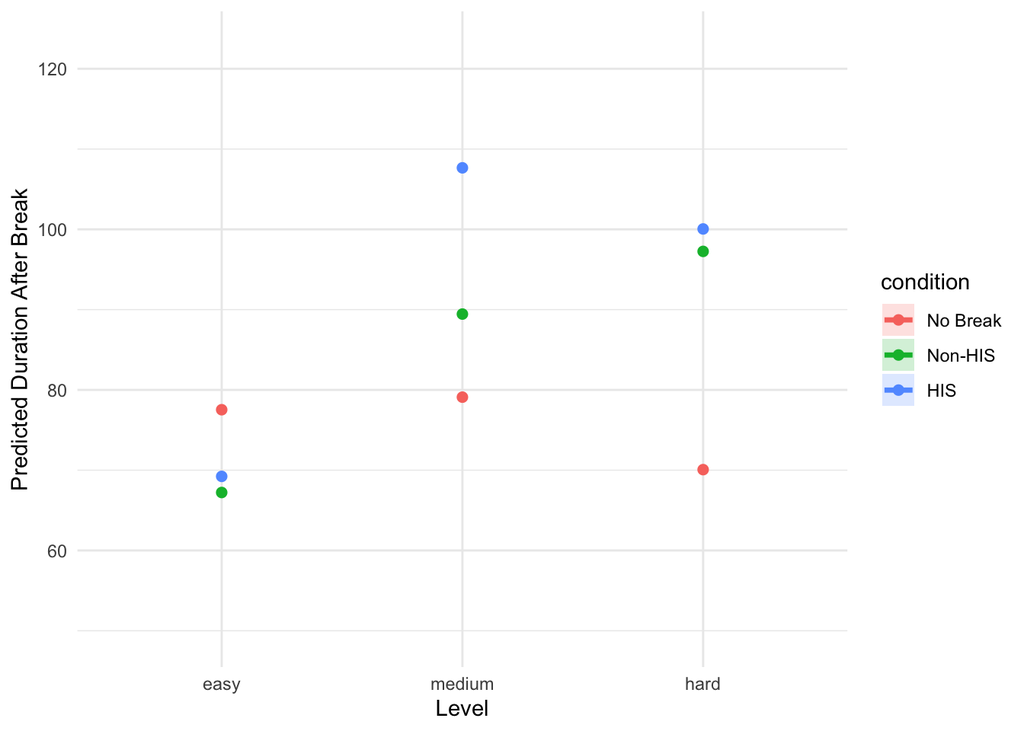

```r
preds <- ggpredict(model2_final, terms = c("level", "condition"))

ggplot(preds, aes(x = x, y = predicted, color = group)) +
  geom_line(linewidth = 1.2) +
  geom_point(size = 2) +
  geom_ribbon(aes(ymin = conf.low, ymax = conf.high, fill = group), alpha = 0.2, color = NA) +
  labs(
    x = "Level",
    y = "Predicted Duration After Break",
    color = "condition",
    fill = "condition"
  ) +
  theme_minimal()
```

## Clustering Analysis

We have a lot of data on the exact moves participants used while working on the puzzles. We can see how strategies shift when participants are interrupted to take a break. We can use clustering in order to cluster strategies by comparing move set similarity in each level. First, we use every participants’ move sets to build a list of every move set made.

```r
data$allMovesets <- Map(c, data$beforeBreakMovesets, data$afterBreakMovesets)

get_cleaned_movesets <- function(level_name) {
  level_rows <- data[data$level == level_name, ]
  combined_movesets <- unlist(level_rows$allMovesets, use.names = FALSE)
  filtered <- combined_movesets[nchar(combined_movesets) >= 4]
  unique(filtered)
}

easy_movesets   <- get_cleaned_movesets("easy")
medium_movesets <- get_cleaned_movesets("medium")
hard_movesets   <- get_cleaned_movesets("hard")
```

For the hard level, there are groups of moves that always occur together. To better identify strategies, we convert these patterns of moves.

```r
hard_movesets <- gsub("rrddllu", "z", hard_movesets)
hard_movesets <- gsub("drruull", "x", hard_movesets)
```

Move sets will be considered similar if they have similar prefixes. For example, lrlrudud would be similar to lrluduu. The more prefixes they have in common, the more likely they are to be similar strategies in Sokoban. We compute a distance matrix for each level.

```r
prefix_distance <- function(a, b) {
  min_len <- min(nchar(a), nchar(b))
  match_length <- 0
  for (i in seq_len(min_len)) {
    if (substr(a, i, i) != substr(b, i, i)) break
    match_length <- match_length + 1
  }
  return(1 - (match_length / min_len))
}

build_prefix_dist_matrix <- function(movesets) {
  n <- length(movesets)
  dist_mat <- matrix(0, n, n)

  for (i in 1:(n-1)) {
    for (j in (i+1):n) {
      d <- prefix_distance(movesets[i], movesets[j])
      dist_mat[i, j] <- d
      dist_mat[j, i] <- d
    }
  }

  as.dist(dist_mat)
}

easy_dist <- build_prefix_dist_matrix(easy_movesets)
medium_dist <- build_prefix_dist_matrix(medium_movesets)
hard_dist <- build_prefix_dist_matrix(hard_movesets)

easy_clust <- hclust(easy_dist, method = "complete")
medium_clust <- hclust(medium_dist, method = "complete")
hard_clust <- hclust(hard_dist, method = "complete")
```

We use silhouette analysis to determine the optimal number of clusters.

Easy Level

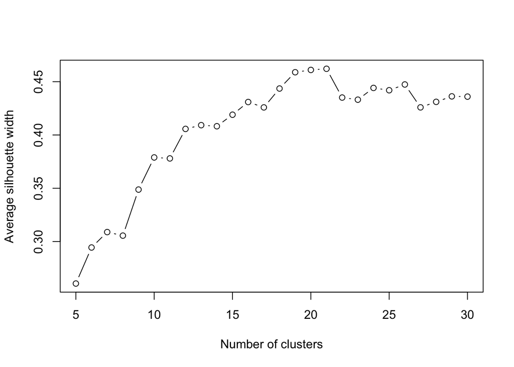

```r
avg_sil <- sapply(5:30, function(k) {
  clusters <- cutree(easy_clust, k)
  sil <- silhouette(clusters, easy_dist)
  mean(sil[, 3])
})

plot(5:30, avg_sil, type = "b",
     xlab = "Number of clusters", ylab = "Average silhouette width")
```

Medium Level

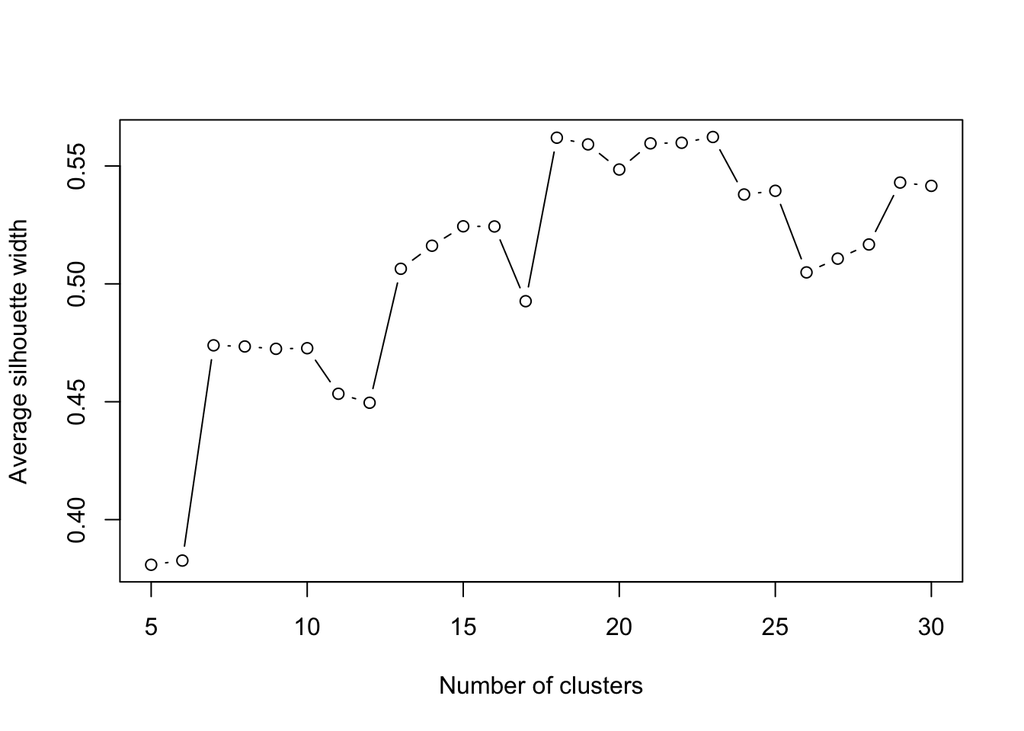

```r
avg_sil <- sapply(5:30, function(k) {
  clusters <- cutree(medium_clust, k)
  sil <- silhouette(clusters, medium_dist)
  mean(sil[, 3])
})

plot(5:30, avg_sil, type = "b",
     xlab = "Number of clusters", ylab = "Average silhouette width")
```

Hard Level

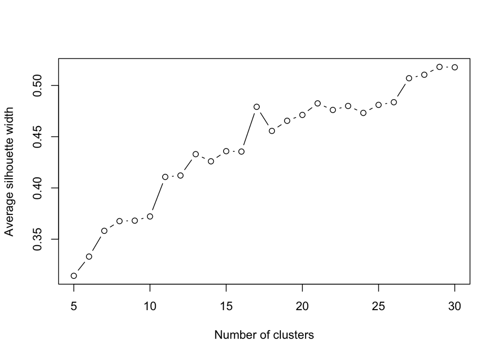

```r
avg_sil <- sapply(5:30, function(k) {
  clusters <- cutree(hard_clust, k)
  sil <- silhouette(clusters, hard_dist)
  mean(sil[, 3])
})

plot(5:30, avg_sil, type = "b",
     xlab = "Number of clusters", ylab = "Average silhouette width")
```

Based on the plots, the number of clusters for the easy, medium, and hard puzzles will be 19, 18, and 17, respectively.

```r
clusters_easy <- cutree(easy_clust, k = 19)
clusters_medium <- cutree(medium_clust, k = 18)
clusters_hard <- cutree(hard_clust, k = 17)
```

We generate new data columns which show the cluster number rather than the string of moves. A very few number of participants did not have move sets before or after break and are removed from this analysis.

```r
main_data$beforeBreakMovesets <- mapply(function(moves, level) {
  moves <- moves[nchar(moves) >= 4]
  if (level == "hard") {
    moves <- gsub("rrddllu", "z", moves)
    moves <- gsub("drruull", "x", moves)


  }
  return(moves)
}, main_data$beforeBreakMovesets, main_data$level, SIMPLIFY = FALSE)

main_data$afterBreakMovesets <- mapply(function(moves, level) {
  moves <- moves[nchar(moves) >= 4]
  if (level == "hard") {
    moves <- gsub("rrddllu", "z", moves)
    moves <- gsub("drruull", "x", moves)
  }

  return(moves)

}, main_data$afterBreakMovesets, main_data$level, SIMPLIFY = FALSE)



moveset_data <- main_data[
  lengths(main_data$beforeBreakMovesets) > 0 &
  lengths(main_data$afterBreakMovesets) > 0,
]


lookup_easy <- setNames(clusters_easy, easy_movesets)
lookup_medium <- setNames(clusters_medium, medium_movesets)
lookup_hard <- setNames(clusters_hard, hard_movesets)

map_moves_to_clusters <- function(moves, level) {
  level <- as.character(level)
  lookup <- switch(level,
                   "easy" = lookup_easy,
                   "medium" = lookup_medium,
                   "hard" = lookup_hard)

  sapply(moves, function(m) lookup[[m]], USE.NAMES = FALSE)
}


moveset_data$beforeClusters <- mapply(map_moves_to_clusters,
                                   moveset_data$beforeBreakMovesets,
                                   moveset_data$level,
                                   SIMPLIFY = FALSE)

moveset_data$afterClusters <- mapply(map_moves_to_clusters,
                                  moveset_data$afterBreakMovesets,
                                  moveset_data$level,
                                  SIMPLIFY = FALSE)
```

We now create a column which displays whether an individual’s first move when returning to the problem after a break is a new strategy (new cluster) or a variation/copy of a previous strategy. We can also just compare the first strategy used in both periods.

We also count the number of moves made before the break for use as a control variable, since using a new strategy is more likely if you have less moves made before the break.

```r
moveset_data$newMove <- mapply(function(before, after) {
  first_after <- after[1]
  if (first_after %in% before) 0 else 1
}, moveset_data$beforeClusters, moveset_data$afterClusters)

moveset_data$firstNewMove <- mapply(function(before, after) {
  if (after[1] == before[1]) 0 else 1
}, moveset_data$beforeClusters, moveset_data$afterClusters)

moveset_data$beforeBreakLength <- sapply(moveset_data$beforeBreakMovesets, length)
```

Let’s check whether different conditions or levels predict the use of new moves.

```r
model3_base <- glmer(newMove ~  level * condition + beforeBreakLength + (1|prolificPID), family="binomial", control = glmerControl(optimizer = "bobyqa"), data = moveset_data)

summary(model3_base)
```

```
## Generalized linear mixed model fit by maximum likelihood (Laplace
##   Approximation) [glmerMod]
##  Family: binomial  ( logit )
## Formula: newMove ~ level * condition + beforeBreakLength + (1 | prolificPID)
##    Data: moveset_data
## Control: glmerControl(optimizer = "bobyqa")
##
##       AIC       BIC    logLik -2*log(L)  df.resid
##     846.1     895.3    -412.1     824.1       635
##
## Scaled residuals:
##     Min      1Q  Median      3Q     Max
## -2.0556 -0.8546  0.3756  0.8052  2.3974
##
## Random effects:
##  Groups      Name        Variance Std.Dev.
##  prolificPID (Intercept) 0.3199   0.5656
## Number of obs: 646, groups:  prolificPID, 297
##
## Fixed effects:
##                              Estimate Std. Error z value Pr(>|z|)
## (Intercept)                   2.24951    0.39860   5.644 1.67e-08 ***
## levelmedium                  -1.02130    0.41652  -2.452   0.0142 *
## levelhard                    -0.84040    0.40188  -2.091   0.0365 *
## conditionNon-HIS             -0.72862    0.44476  -1.638   0.1014
## conditionHIS                 -1.06702    0.45602  -2.340   0.0193 *
## beforeBreakLength            -0.28467    0.04685  -6.077 1.23e-09 ***
## levelmedium:conditionNon-HIS  0.11397    0.58648   0.194   0.8459
## levelhard:conditionNon-HIS    0.68443    0.56054   1.221   0.2221
## levelmedium:conditionHIS      0.87921    0.59451   1.479   0.1392
## levelhard:conditionHIS        0.77049    0.56737   1.358   0.1745
## ---
## Signif. codes:  0 '***' 0.001 '**' 0.01 '*' 0.05 '.' 0.1 ' ' 1
##
## Correlation of Fixed Effects:
##             (Intr) lvlmdm lvlhrd cN-HIS cndHIS bfrBrL lvlm:N-HIS lvlh:N-HIS
## levelmedium -0.682
## levelhard   -0.700  0.642
## cndtnNn-HIS -0.608  0.590  0.605
## conditinHIS -0.623  0.578  0.595  0.531
## bfrBrkLngth -0.569  0.061  0.059  0.004  0.055
## lvlmd:N-HIS  0.465 -0.717 -0.459 -0.768 -0.406 -0.002
## lvlhr:N-HIS  0.474 -0.464 -0.725 -0.802 -0.424  0.018  0.608
## lvlmdm:cHIS  0.483 -0.713 -0.456 -0.415 -0.778 -0.039  0.503      0.327
## lvlhrd:cHIS  0.509 -0.462 -0.724 -0.427 -0.813 -0.053  0.326      0.513
##             lvlm:HIS
## levelmedium
## levelhard
## cndtnNn-HIS
## conditinHIS
## bfrBrkLngth
## lvlmd:N-HIS
## lvlhr:N-HIS
## lvlmdm:cHIS
## lvlhrd:cHIS  0.623
```

```r
preds <- ggpredict(model3_base, terms = c("level", "condition"))
```

```
## You are calculating adjusted predictions on the population-level (i.e.
##   `type = "fixed"`) for a *generalized* linear mixed model.
##   This may produce biased estimates due to Jensen's inequality. Consider
##   setting `bias_correction = TRUE` to correct for this bias.
##   See also the documentation of the `bias_correction` argument.
```

```
## `geom_line()`: Each group consists of only one observation.
## ℹ Do you need to adjust the group aesthetic?
```

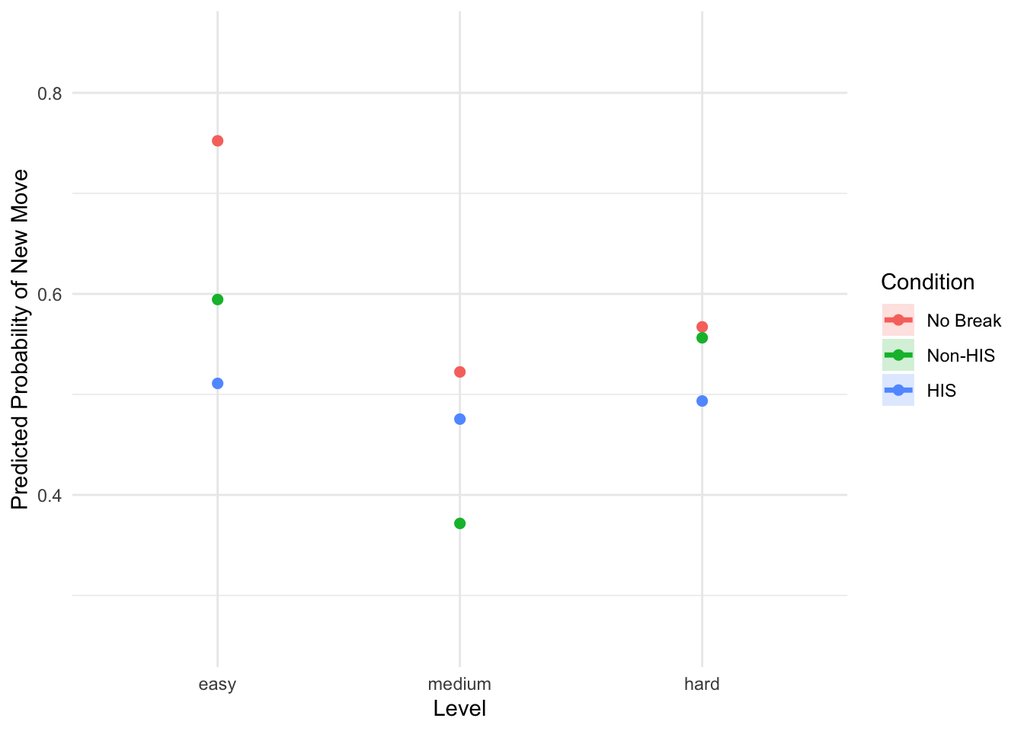

```r
ggplot(preds, aes(x = x, y = predicted, color = group)) +
  geom_line(linewidth = 1.2) +
  geom_point(size = 2) +
  geom_ribbon(aes(ymin = conf.low, ymax = conf.high, fill = group), alpha = 0.2, color = NA) +
  labs(
    x = "Level",
    y = "Predicted Probability of New Move",
    color = "Condition",
    fill = "Condition"
  ) +
  theme_minimal()
```

We can check whether using new moves affects completion likelihood or completion duration.

```r
model4_base <- glmer(completedLevel ~  level * newMove + (1|prolificPID), family="binomial", control = glmerControl(optimizer = "bobyqa"), data = moveset_data)

summary(model4_base)
```

```
## Generalized linear mixed model fit by maximum likelihood (Laplace
##   Approximation) [glmerMod]
##  Family: binomial  ( logit )
## Formula: completedLevel ~ level * newMove + (1 | prolificPID)
##    Data: moveset_data
## Control: glmerControl(optimizer = "bobyqa")
##
##       AIC       BIC    logLik -2*log(L)  df.resid
##     724.1     755.4    -355.0     710.1       639
##
## Scaled residuals:
##     Min      1Q  Median      3Q     Max
## -0.9321 -0.6064 -0.3804  0.9477  2.6307
##
## Random effects:
##  Groups      Name        Variance Std.Dev.
##  prolificPID (Intercept) 0.6292   0.7932
## Number of obs: 646, groups:  prolificPID, 297
##
## Fixed effects:
##                     Estimate Std. Error z value Pr(>|z|)
## (Intercept)         -0.62735    0.28689  -2.187  0.02876 *
## levelmedium         -0.07450    0.35208  -0.212  0.83241
## levelhard           -1.06061    0.38628  -2.746  0.00604 **
## newMove              0.06836    0.37493   0.182  0.85534
## levelmedium:newMove -0.16689    0.49399  -0.338  0.73549
## levelhard:newMove   -0.60290    0.52918  -1.139  0.25458
## ---
## Signif. codes:  0 '***' 0.001 '**' 0.01 '*' 0.05 '.' 0.1 ' ' 1
##
## Correlation of Fixed Effects:
##             (Intr) lvlmdm lvlhrd newMov lvlm:M
## levelmedium -0.788
## levelhard   -0.711  0.611
## newMove     -0.757  0.623  0.588
## lvlmdm:nwMv  0.575 -0.729 -0.438 -0.749
## lvlhrd:nwMv  0.538 -0.447 -0.715 -0.708  0.537
```

```
## `geom_line()`: Each group consists of only one observation.
## ℹ Do you need to adjust the group aesthetic?
```

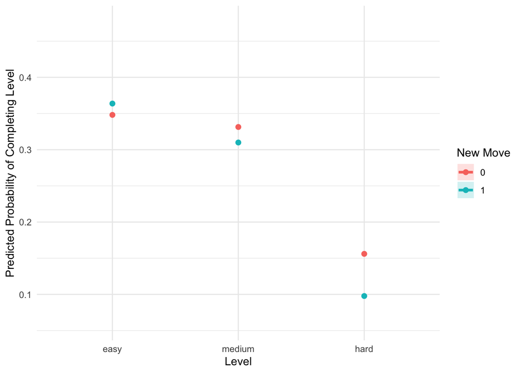

```r
preds <- ggpredict(model4_base, terms = c("level", "newMove"))

ggplot(preds, aes(x = x, y = predicted, color = group)) +
  geom_line(linewidth = 1.2) +
  geom_point(size = 2) +
  geom_ribbon(aes(ymin = conf.low, ymax = conf.high, fill = group), alpha = 0.2, color = NA) +
  labs(
    x = "Level",
    y = "Predicted Probability of Completing Level",
    color = "New Move",
    fill = "New Move"
  ) +
  theme_minimal()
```

```r
completed_moveset_data <- moveset_data %>%
  filter(completedLevel == 1)

model5_base <- lmer(durationAfterBreak ~  level* newMove + (1|prolificPID), data = completed_moveset_data)

summary(model5_base)
```

```
## Linear mixed model fit by REML. t-tests use Satterthwaite's method [
## lmerModLmerTest]
## Formula: durationAfterBreak ~ level * newMove + (1 | prolificPID)
##    Data: completed_moveset_data
##
## REML criterion at convergence: 1733.3
##
## Scaled residuals:
##     Min      1Q  Median      3Q     Max
## -1.7917 -0.7911 -0.1210  0.7719  2.1148
##
## Random effects:
##  Groups      Name        Variance Std.Dev.
##  prolificPID (Intercept)  119.1   10.91
##  Residual                1456.3   38.16
## Number of obs: 174, groups:  prolificPID, 140
##
## Fixed effects:
##                     Estimate Std. Error       df t value Pr(>|t|)
## (Intercept)          81.5432     8.0932 167.6201  10.076  < 2e-16 ***
## levelmedium          -1.8859    10.0815 164.6476  -0.187  0.85184
## levelhard             0.2868    11.4079 160.2379   0.025  0.97998
## newMove             -16.2255    10.4459 167.1742  -1.553  0.12224
## levelmedium:newMove  40.1307    14.0152 167.5877   2.863  0.00473 **
## levelhard:newMove    26.2792    16.5473 167.9545   1.588  0.11414
## ---
## Signif. codes:  0 '***' 0.001 '**' 0.01 '*' 0.05 '.' 0.1 ' ' 1
##
## Correlation of Fixed Effects:
##             (Intr) lvlmdm lvlhrd newMov lvlm:M
## levelmedium -0.800
## levelhard   -0.705  0.567
## newMove     -0.775  0.622  0.554
## lvlmdm:nwMv  0.581 -0.725 -0.416 -0.745
## lvlhrd:nwMv  0.491 -0.394 -0.698 -0.634  0.473
```

```
## `geom_line()`: Each group consists of only one observation.
## ℹ Do you need to adjust the group aesthetic?
```

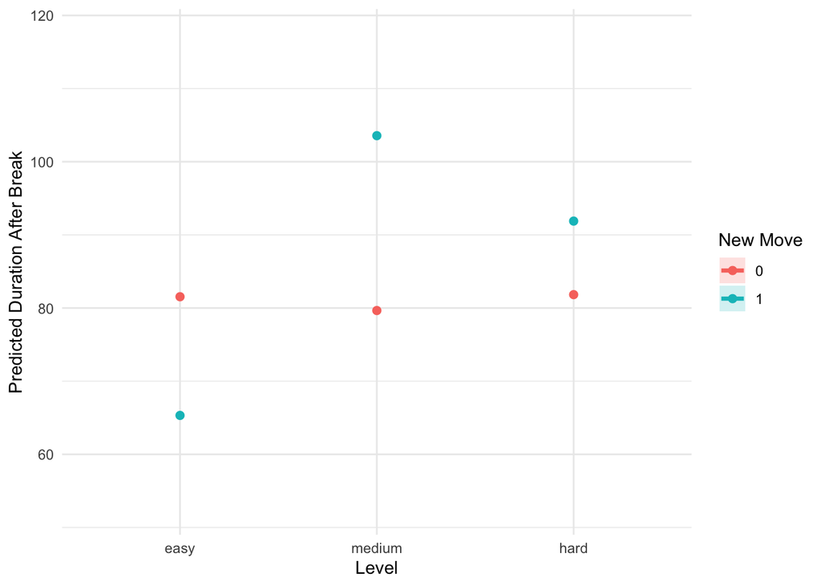

```r
preds <- ggpredict(model5_base, terms = c("level", "newMove"))

ggplot(preds, aes(x = x, y = predicted, color = group)) +
  geom_line(linewidth = 1.2) +
  geom_point(size = 2) +
  geom_ribbon(aes(ymin = conf.low, ymax = conf.high, fill = group), alpha = 0.2, color = NA) +
  labs(
    x = "Level",
    y = "Predicted Duration After Break",
    color = "New Move",
    fill = "New Move"
  ) +
  theme_minimal()
```

There is some evidence that using new strategies is helpful only for the easy puzzle, but not helpful for the harder puzzles. However, recall that breaks reduced the likelihood of using new moves for the easy puzzle, but this did not result in significant performance losses (model 1 and 2).

The relationship between new strategies and increased performance is not obvious. Why does it benefit the easy puzzle, but not the harder ones? We can explore the most common strategies used and compare them to the winning moves.

```r
counts <- table(clusters_easy)
props <- counts / length(clusters_easy)
easy_prop <- data.frame(
    cluster = names(counts),
    proportion = round(as.numeric(props) * 100, 2)
)
print(easy_prop)
```

```
##    cluster proportion
## 1        1       8.52
## 2        2      11.66
## 3        3       2.69
## 4        4      21.19
## 5        5       3.03
## 6        6      10.65
## 7        7       2.91
## 8        8       5.16
## 9        9       7.29
## 10      10       2.35
## 11      11       3.48
## 12      12       7.74
## 13      13       4.04
## 14      14       3.03
## 15      15       1.23
## 16      16       3.92
## 17      17       0.78
## 18      18       0.22
## 19      19       0.11
```

For the easy puzzle, the winning strategies come from cluster 1 and 14. These together make up around 12% of the moves used. It was far more common to use strategies from other clusters (such as cluster 4). Therefore, shifting strategies is helpful here. It would not be beneficial to explore the more commonly exploited clusters.

```r
counts <- table(clusters_medium)
props <- counts / length(clusters_medium)
medium_prop <- data.frame(
    cluster = names(counts),
    proportion = round(as.numeric(props) * 100, 2)
)
print(medium_prop)
```

```
##    cluster proportion
## 1        1       8.92
## 2        2      12.66
## 3        3      19.50
## 4        4      23.65
## 5        5       9.75
## 6        6       5.19
## 7        7       9.96
## 8        8       5.39
## 9        9       0.83
## 10      10       1.66
## 11      11       0.21
## 12      12       0.21
## 13      13       0.62
## 14      14       0.21
## 15      15       0.21
## 16      16       0.21
## 17      17       0.21
## 18      18       0.62
```

The winning strategies for the medium puzzle come from cluster 3. This makes up around 20% of the moves used.

```r
counts <- table(clusters_hard)
props <- counts / length(clusters_hard)
hard_prop <- data.frame(
    cluster = names(counts),
    proportion = round(as.numeric(props) * 100, 2)
)
print(hard_prop)
```

```
##    cluster proportion
## 1        1      12.97
## 2        2      16.12
## 3        3       6.68
## 4        4      12.85
## 5        5      16.50
## 6        6       3.90
## 7        7       0.76
## 8        8       3.02
## 9        9       4.53
## 10      10      11.84
## 11      11       0.13
## 12      12       5.54
## 13      13       0.13
## 14      14       1.89
## 15      15       1.64
## 16      16       0.76
## 17      17       0.76
```

The winning strategies for the hard puzzle come from cluster 4, 5, and 10. This makes up around 41% of the moves used.